# 04 – Co-Occurrence and Network Visualizations (ADM + No Cancer, stratified by ABX)

Blake Hanson, PhD

2026-01-12

# Goal for this section

In this notebook, we move beyond **sample-level comparisons** and explore **relationships between taxa** using **co-occurrence networks**.

Network analyses are great exploratory analyses and visualizations, but are notoriously uninterpretable. To make these networks interpretable, we will analyze the same clinical subset used in Figures 5 and 6 of our [publication](https://journals.asm.org/doi/10.1128/spectrum.01430-23?url_ver=Z39.88-2003&rfr_id=ori:rid:crossref.org&rfr_dat=cr_pub%20%200pubmed):

To get to the analyzed dataset for those figures, we will subset our phyloseq object to: - Material = ADM - CancerSideSample = No - Compare networks by **ABX (TAPI): Yes vs No**

By the end of this notebook you will be able to:

1. Explain what microbial co-occurrence *does* and *does not* mean
2. Subset a phyloseq object using metadata (ADM + no cancer)
3. Build separate co-occurrence networks for ABX=Yes vs ABX=No
4. Filter taxa and edges to reduce noise and false positives
5. Visualize networks and interpret them responsibly

> **Important context:** co-occurrence networks are **exploratory and hypothesis-generating**.  
> Correlation ≠ interaction ≠ causation.

# Background: what is co-occurrence?

Before writing code, it is critical to understand what we are measuring.

### What co-occurrence *is*

- A statistical association between taxa across samples
- Often summarized as a correlation (positive or negative)
- A way to describe patterns of co-variation

### What co-occurrence is *not*

- Proof that taxa interact directly
- Evidence of competition or cooperation
- Causal inference

> Two taxa can appear correlated because they share niches, respond to the same unmeasured factor, or because microbiome data are **compositional** (constant-sum constraints can induce correlations).

> **Tip for Posit Cloud:** Run each code chunk in order using the green “Run” button.

## Step 1 — Load the phyloseq object

This notebook assumes you have created a `phyloseq_object` in **Notebook 01**.

## Step 2 — Subset to the clinical comparison (ADM + no cancer) and check ABX groups

We will restrict to:

- `CancerSideSample == "No"`
- `Material == "ADM"`
- non-missing `ABX`

```r
# Subset to patients without cancer
ps_nocancer <- subset_samples(phyloseq_object, CancerSideSample == "No")
ps_nocancer_adm <- subset_samples(ps_nocancer, Material == "ADM")

# Remove samples with missing ABX status
ps_nocancer_adm <- subset_samples(ps_nocancer_adm, !is.na(ABX))

# Drop taxa with zero counts after subsetting
ps_nocancer_adm <- prune_taxa(taxa_sums(ps_nocancer_adm) > 0, ps_nocancer_adm)

ps_nocancer_adm
```

```
## phyloseq-class experiment-level object
## otu_table()   OTU Table:         [ 304 taxa and 16 samples ]
## sample_data() Sample Data:       [ 16 samples by 11 sample variables ]
## tax_table()   Taxonomy Table:    [ 304 taxa by 6 taxonomic ranks ]
```

Before building networks, confirm the number of samples per ABX group. Based on the design of the study, this should be 16 total ADM samples and 8 samples per ABX group.

```r
table(sample_data(ps_nocancer_adm)$ABX, useNA = "ifany")
```

```
##
##  No Yes
##   8   8
```

> Note for other analyses: If one group has very few samples, correlation estimates will be unstable and networks may look sparse or noisy.

## Step 3 — Split into ABX=No and ABX=Yes phyloseq objects

Next, we will build **two** co-occurrence networks: - one using only ABX=No samples - one using only ABX=Yes samples

```r
# Subset the phyloseq object into the two objects that represent the two ABX categories
ps_abx_no  <- subset_samples(ps_nocancer_adm, ABX == "No")
ps_abx_yes <- subset_samples(ps_nocancer_adm, ABX == "Yes")

# Drop taxa that become all-zero within each group
ps_abx_no  <- prune_taxa(taxa_sums(ps_abx_no)  > 0, ps_abx_no)
ps_abx_yes <- prune_taxa(taxa_sums(ps_abx_yes) > 0, ps_abx_yes)

# Let's look at the summary data for our two new phyloseq objects
ps_abx_no
```

```
## phyloseq-class experiment-level object
## otu_table()   OTU Table:         [ 185 taxa and 8 samples ]
## sample_data() Sample Data:       [ 8 samples by 11 sample variables ]
## tax_table()   Taxonomy Table:    [ 185 taxa by 6 taxonomic ranks ]
```

```r
ps_abx_yes
```

```
## phyloseq-class experiment-level object
## otu_table()   OTU Table:         [ 189 taxa and 8 samples ]
## sample_data() Sample Data:       [ 8 samples by 11 sample variables ]
## tax_table()   Taxonomy Table:    [ 189 taxa by 6 taxonomic ranks ]
```

## Step 4 — Prepare data for correlation analysis (relative abundance + prevalence filter)

Correlation methods expect a samples × taxa matrix.

We will: 1. Convert our count table to relative abundance (within each ABX group) 2. Filter out rare taxa by prevalence (to reduce spurious correlations)

Why prevalence filtering matters: - Rare taxa appear in very few samples - That sparsity can inflate correlation estimates and produce dense/noisy networks

```r
# Workshop defaults (tune for your dataset)
min_prev_prop <- 0.20   # keep taxa present in at least 20% of samples (within each ABX group)
rho_threshold <- 0.60   # keep correlations with |rho| >= this value

# Let's print the values we have set to make sure everything is stored appropriately and recorded
print(paste("The minimum prevalence proportion is:", min_prev_prop))
```

```
## [1] "The minimum prevalence proportion is: 0.2"
```

```r
print(paste("The minimum rho threshold is:", rho_threshold))
```

```
## [1] "The minimum rho threshold is: 0.6"
```

Next, we are going to build a helper function that we will run for both phyloseq objects to build our correlation networks.

```r
# Helper function to: phyloseq -> filtered sample x taxa matrix (relative abundance) -> correlation edge list -> igraph
build_cooccurrence_network <- function(ps, group_label, min_prev_prop = 0.20, rho_threshold = 0.60) {

  # 1) Transform to relative abundance (each sample sums to 1)
  ps_rel <- transform_sample_counts(ps, function(x) x / sum(x))

  # 2) Extract OTU table matrix
  otu_mat <- as(otu_table(ps_rel), "matrix")

  # Ensure samples are rows and taxa are columns
  if (taxa_are_rows(ps_rel)) {
    otu_mat <- t(otu_mat)
  }

  # Quick standard check to make sure we have enough samples and taxa for our assessment (we do, but this is helpful for your own work)
  if (nrow(otu_mat) < 4) {
    stop("Group '", group_label, "' has <4 samples. Correlations will not be stable.")
  }
  if (ncol(otu_mat) < 3) {
    stop("Group '", group_label, "' has <3 taxa after subsetting. Network will be empty.")
  }

  # 3) Prevalence filtering
  min_prevalence <- ceiling(min_prev_prop * nrow(otu_mat))
  taxa_prev <- colSums(otu_mat > 0)
  keep_taxa <- names(taxa_prev[taxa_prev >= min_prevalence])

  otu_filt <- otu_mat[, keep_taxa, drop = FALSE]

  # 4) Correlation matrix (Spearman)
  cor_mat <- suppressWarnings(cor(otu_filt, method = "spearman"))

  # 5) Convert to edge list
  cor_df <- as.data.frame(cor_mat) %>%
    rownames_to_column("Taxon1") %>%
    pivot_longer(-Taxon1, names_to = "Taxon2", values_to = "rho") %>%
    filter(Taxon1 < Taxon2) %>%                           # keep each pair once
    filter(!is.na(rho)) %>%
    filter(abs(rho) >= rho_threshold)

  # If no edges survive, return an empty graph with nodes
  if (nrow(cor_df) == 0) {
    g <- make_empty_graph(n = ncol(otu_filt), directed = FALSE)
    V(g)$name <- colnames(otu_filt)
    V(g)$group <- group_label
    return(list(graph = g, edges = cor_df, otu_filt = otu_filt))
  }

  # 6) Build graph
  g <- graph_from_data_frame(cor_df, directed = FALSE, vertices = data.frame(name = colnames(otu_filt)))

  # Add attributes
  E(g)$sign <- ifelse(E(g)$rho > 0, "positive", "negative")
  V(g)$group <- group_label

  return(list(graph = g, edges = cor_df, otu_filt = otu_filt))
}
```

Now we build the networks for each ABX group.

```r
# Build the co-occurrence networks
net_no  <- build_cooccurrence_network(ps_abx_no,  group_label = "ABX = No",  min_prev_prop = min_prev_prop, rho_threshold = rho_threshold)
net_yes <- build_cooccurrence_network(ps_abx_yes, group_label = "ABX = Yes", min_prev_prop = min_prev_prop, rho_threshold = rho_threshold)

# Print the summary information on the networks
net_no$graph
```

```
## IGRAPH d5de3fa UN-- 49 104 --
## + attr: name (v/c), group (v/c), rho (e/n), sign (e/c)
## + edges from d5de3fa (vertex names):
##  [1] OTU13  --OTU371  OTU1   --OTU497  OTU1   --OTU297  OTU1629--OTU41
##  [5] OTU17  --OTU52   OTU17  --OTU530  OTU17  --OTU28   OTU17  --OTU329
##  [9] OTU17  --OTU863  OTU17  --OTU497  OTU1876--OTU5    OTU1876--OTU92
## [13] OTU1975--OTU92   OTU17  --OTU151  OTU151 --OTU52   OTU151 --OTU530
## [17] OTU151 --OTU329  OTU151 --OTU863  OTU52  --OTU530  OTU52  --OTU863
## [21] OTU4   --OTU83   OTU13  --OTU12   OTU12  --OTU23   OTU12  --OTU31
## [25] OTU12  --OTU32   OTU12  --OTU138  OTU12  --OTU1756 OTU12  --OTU55
## [29] OTU41  --OTU23   OTU23  --OTU31   OTU23  --OTU32   OTU23  --OTU497
## + ... omitted several edges
```

```r
net_yes$graph
```

```
## IGRAPH 9050a8f UN-- 62 236 --
## + attr: name (v/c), group (v/c), rho (e/n), sign (e/c)
## + edges from 9050a8f (vertex names):
##  [1] OTU13  --OTU304  OTU13  --OTU21   OTU13  --OTU18   OTU1   --OTU31
##  [5] OTU1   --OTU11   OTU1   --OTU269  OTU1   --OTU307  OTU1   --OTU79
##  [9] OTU17  --OTU1975 OTU17  --OTU52   OTU17  --OTU5    OTU17  --OTU23
## [13] OTU17  --OTU1756 OTU785 --OTU8    OTU1975--OTU5    OTU1975--OTU8
## [17] OTU52  --OTU59   OTU5   --OTU8    OTU17  --OTU12   OTU1975--OTU12
## [21] OTU12  --OTU23   OTU12  --OTU1756 OTU12  --OTU1983 OTU12  --OTU225
## [25] OTU12  --OTU37   OTU12  --OTU61   OTU12  --OTU807  OTU4   --OTU23
## [29] OTU31  --OTU32   OTU31  --OTU79   OTU52  --OTU27   OTU32  --OTU79
## + ... omitted several edges
```

## Step 5 — Add taxonomy labels (optional but recommended)

OTU IDs are unique but not very interpretable.

Here we build a simple node label using Genus when available: - `Genus` if present - otherwise fall back to the OTU/Taxon ID

```r
# Extract taxonomy table from the parent subset (ADM + no cancer)
tax_tbl <- as.data.frame(tax_table(ps_nocancer_adm), stringsAsFactors = FALSE)

make_node_labels <- function(g, tax_tbl) {
  taxa_ids <- V(g)$name

  # Safe lookup for genus (some datasets use lowercase "genus")
  genus <- rep(NA_character_, length(taxa_ids))
  if ("genus" %in% colnames(tax_tbl)) {
    genus <- as.character(tax_tbl[taxa_ids, "genus"])
  } else if ("Genus" %in% colnames(tax_tbl)) {
    genus <- as.character(tax_tbl[taxa_ids, "Genus"])
  }

  genus_clean <- ifelse(is.na(genus) | genus == "" | genus %in% c("NA","N/A","unclassified"), NA, genus)
  label <- ifelse(is.na(genus_clean), taxa_ids, paste0(taxa_ids, " – ", genus_clean))

  V(g)$label <- label
  g
}

net_no$graph  <- make_node_labels(net_no$graph, tax_tbl)
net_yes$graph <- make_node_labels(net_yes$graph, tax_tbl)

# Quick peek
head(V(net_no$graph)$label)
```

```
## [1] "OTU13 – Staphylococcus"    "OTU1 – Propionibacterium"
## [3] "OTU1629 – Corynebacterium" "OTU41 – Corynebacterium"
## [5] "OTU17 – Corynebacterium"   "OTU1876 – Micrococcus"
```

## Step 6 — Visualize the ABX-specific networks

We will plot the **ABX = No** and **ABX = Yes** networks side-by-side so we can compare:

- number of nodes and edges
- whether associations are mostly positive or negative
- which taxa appear highly connected (potential “hubs”)

> **Reminder:** Differences in network appearance can reflect biology *or* differences in sample size, sparsity, and filtering. Treat these as exploratory visuals.

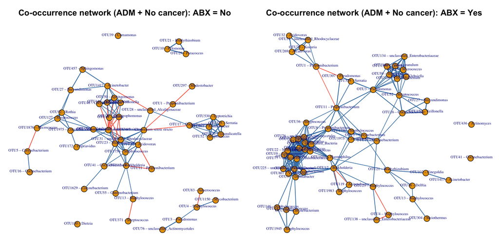

```r
set.seed(1234)

# Generate the network plot. If no edges remain after filtering, plotting will fail. Instead, show a clear message explaining this.
plot_one_network <- function(g, main_title) {
  if (ecount(g) == 0) {
    plot.new()
    title(main_title)
    text(0.5, 0.5, "No edges passed filtering.\nTry lowering rho_threshold or min_prev_prop.", cex = 0.9)
    return(invisible(NULL))
  }

  # Compute a force-directed layout (Fruchterman–Reingold). This places highly connected nodes closer together.
  lay <- layout_with_fr(g)

  # Plot the network
  plot(
    g,
    layout = lay,
    vertex.size = 6,
    vertex.label = V(g)$label,
    vertex.label.cex = 0.55,
    vertex.label.dist = 0.2,
    edge.width = pmax(1, abs(E(g)$rho) * 2),
    edge.color = ifelse(E(g)$rho > 0, "steelblue", "tomato"),
    main = main_title
  )
}

# We use a 1x2 layout so that ABX = No and ABX = Yes networks can be compared visually.
par(mfrow = c(1, 2), mar = c(1, 1, 3, 1))
plot_one_network(net_no$graph,  "Co-occurrence network (ADM + No cancer): ABX = No")
plot_one_network(net_yes$graph, "Co-occurrence network (ADM + No cancer): ABX = Yes")
```

```r
par(mfrow = c(1, 1))
```

## Step 7 — Compare networks with simple summary statistics

To help interpret co-occurrence networks, it is helpful to quantify their overall structure using simple summary metrics. Two commonly used metrics are density and transitivity:

**Network density** is: - how connected a network is overall - calculated as the proportion of observed edges relative to the maximum number of possible edges in the network.

Density ranges from 0 to 1: - Density ≈ 0 is a very sparse network (few taxon–taxon associations detected) - Density ≈ 1 is a very dense network (many taxa connected to many others)

Interpretation in microbiome networks: - Higher density suggests widespread co-variation among taxa - Lower density suggests more isolated or specialized associations - Density is highly sensitive to filtering thresholds (prevalence cutoffs, correlation cutoffs)

> Density does not indicate interaction strength or biological importance—only how many associations remain after filtering.

**Transitivity* is a global clustering coefficient that measures: - the tendency of nodes to form closed triplets, or “triangles.”

This means it is asking *If taxon A is correlated with taxon B, and taxon B is correlated with taxon C, how often is taxon A also correlated with taxon C?*

Like density, transitivity ranges from 0 to 1: - Low transitivity (≈ 0) indicates associations are mostly linear or chain-like - High transitivity (≈ 1) indicates taxa tend to form tightly connected clusters

Interpretation in microbiome networks: - High transitivity may indicate groups of taxa that consistently co-vary together - These clusters can reflect shared ecological niches or common responses to environmental or host factors - Transitivity is often interpreted as a measure of network modularity or cohesion

As with density, transitivity is descriptive and exploratory—it does not imply causation or direct interaction.

These are not formal tests, but they help quantify differences you can see by eye.

```r
# Create summary statistics (density and transitivity) for the two networks.
summarize_network <- function(g) {
  data.frame(
    nodes = vcount(g),
    edges = ecount(g),
    density = edge_density(g, loops = FALSE),
    transitivity = transitivity(g, type = "global", isolates = "zero"),
    stringsAsFactors = FALSE
  )
}

# Print the two summaries.
rbind(
  `ABX = No`  = summarize_network(net_no$graph),
  `ABX = Yes` = summarize_network(net_yes$graph)
)
```

```
##           nodes edges    density transitivity
## ABX = No     49   104 0.08843537    0.5760870
## ABX = Yes    62   236 0.12480169    0.7133676
```

You can also list the most connected taxa (“hubs”) in each network.

```r
top_hubs <- function(g, n = 10) {
  if (vcount(g) == 0) return(NULL)
  deg <- degree(g, mode = "all")
  tibble(
    TaxonID = names(deg),
    Degree = as.integer(deg),
    Label = V(g)$label
  ) %>%
    arrange(desc(Degree)) %>%
    slice_head(n = min(n, nrow(.)))
}

top_hubs(net_no$graph, n = 10)
```

```
## # A tibble: 10 × 3
##    TaxonID Degree Label
##    <chr>    <int> <chr>
##  1 OTU138      13 OTU138 – unclassified_Enterobacteriaceae
##  2 OTU23       10 OTU23 – Staphylococcus
##  3 OTU31       10 OTU31 – unclassified_Rhodocyclaceae
##  4 OTU12        8 OTU12 – Burkholderia
##  5 OTU20        8 OTU20 – Stenotrophomonas
##  6 OTU18        8 OTU18 – Delftia
##  7 OTU17        7 OTU17 – Corynebacterium
##  8 OTU32        7 OTU32 – Acidovorax
##  9 OTU1756      7 OTU1756 – Staphylococcus
## 10 OTU146       7 OTU146 – Staphylococcus
```

```r
top_hubs(net_yes$graph, n = 10)
```

```
## # A tibble: 10 × 3
##    TaxonID Degree Label
##    <chr>    <int> <chr>
##  1 OTU10       18 OTU10 – Pelomonas
##  2 OTU77       16 OTU77 – unclassified_Caulobacteraceae
##  3 OTU22       16 OTU22 – Methylobacterium
##  4 OTU19       16 OTU19 – Sphingomonas
##  5 OTU187      16 OTU187 – Turicella
##  6 OTU785      15 OTU785 – Streptococcus
##  7 OTU117      15 OTU117 – Gemella
##  8 OTU57       15 OTU57 – Corynebacterium
##  9 OTU67       15 OTU67 – Sphingomonas
## 10 OTU76       15 OTU76 – unclassified_Actinomycetales
```

## Interpreting co-occurrence networks responsibly

### What you *can* say

- Which taxa tend to co-vary across samples within a group
- Whether associations are mostly positive or negative
- Which taxa are highly connected (candidate “hubs”)

### What you *cannot* say

- Direction of interaction
- Mechanistic relationships
- Clinical causality

> Networks summarize patterns, not mechanisms.

# Summary

In this notebook, we:

- Subset the dataset to a clinically meaningful comparison (**ADM**, **no cancer**)
- Built **ABX-stratified** co-occurrence networks (ABX=No vs ABX=Yes)
- Filtered taxa by prevalence and edges by correlation threshold to reduce noise
- Visualized networks and summarized network structure and hub taxa
- Emphasized responsible interpretation (exploratory, hypothesis-generating)

In the next section, we will build on these ideas and show additional ways to **link microbiome patterns to metadata**, including constrained ordination and correlation-based visual summaries.